# Project Description

In this project, we will explore data about **penguins in Antarctica** using **unsupervised learning**. Our goal is to discover **hidden patterns and natural groupings** (clusters) among the penguins based on their physical features.

## Background

A team of researchers studying penguins in Antarctica has been collecting data, and they’ve asked for our help! They believe there are **at least three penguin species**—**Adelie**, **Chinstrap**, and **Gentoo**—but unfortunately, they did not record the species labels in the dataset.

We’ve been given the dataset in CSV format as:  
`penguins.csv`

### Dataset Information

**Source:**  
Data collected by Dr. Kristen Gorman and the Palmer Station, Antarctica LTER, part of the Long Term Ecological Research Network.

**Features Available:**

| Column | Description |
| --- | --- |
| `culmen_length_mm` | Length of the penguin's bill (mm) |
| `culmen_depth_mm` | Depth of the penguin's bill (mm) |
| `flipper_length_mm` | Length of the flipper (mm) |
| `body_mass_g` | Body mass (grams) |
| `sex` | Penguin’s sex (Male/Female) |

## Our Task

We will:

1. **Explore** and **process** the data.
2. Perform **clustering analysis** to identify natural groups of penguins.
3. Decide on a **reasonable number of clusters** (hint: we expect ~3 species).
4. Analyze and compare the **average feature values** for each cluster.

## Final Outcome

By using unsupervised learning techniques like **K-Means Clustering**, we aim to:

- Group penguins into distinct clusters.
- Provide meaningful insights to the research team.
- Possibly help them **identify penguin species** based on the cluster patterns.

Let’s dive in!

```python
# Import Required libraries
import pandas as pd
import matplotlib.pyplot as plt
from sklearn.cluster import KMeans
from sklearn.preprocessing import StandardScaler
```

```python
# Loading and examining the dataset
penguins_df = pd.read_csv("penguins.csv")
penguins_df.head()
```

|  | culmen_length_mm | culmen_depth_mm | flipper_length_mm | body_mass_g | sex |
| --- | --- | --- | --- | --- | --- |
| 0 | 39.1 | 18.7 | 181.0 | 3750.0 | MALE |
| 1 | 39.5 | 17.4 | 186.0 | 3800.0 | FEMALE |
| 2 | 40.3 | 18.0 | 195.0 | 3250.0 | FEMALE |
| 3 | 36.7 | 19.3 | 193.0 | 3450.0 | FEMALE |
| 4 | 39.3 | 20.6 | 190.0 | 3650.0 | MALE |

```python
penguins_df.info()
```

```
<class 'pandas.core.frame.DataFrame'>
RangeIndex: 332 entries, 0 to 331
Data columns (total 5 columns):
 #   Column             Non-Null Count  Dtype
---  ------             --------------  -----
 0   culmen_length_mm   332 non-null    float64
 1   culmen_depth_mm    332 non-null    float64
 2   flipper_length_mm  332 non-null    float64
 3   body_mass_g        332 non-null    float64
 4   sex                332 non-null    object
dtypes: float64(4), object(1)
memory usage: 13.1+ KB
```

```python
# Convert categorical variables into dummy/indicator variables
penguins_df = pd.get_dummies(penguins_df, dtype='int')
```

```python
# Scaling variables
scaler = StandardScaler()
X = scaler.fit_transform(penguins_df)
penguins_preprocessed = pd.DataFrame(data=X,columns=penguins_df.columns)
penguins_preprocessed.head()
```

|  | culmen_length_mm | culmen_depth_mm | flipper_length_mm | body_mass_g | sex_FEMALE | sex_MALE |
| --- | --- | --- | --- | --- | --- | --- |
| 0 | -0.903906 | 0.790360 | -1.425342 | -0.566948 | -0.993994 | 0.993994 |
| 1 | -0.830434 | 0.126187 | -1.068577 | -0.504847 | 1.006042 | -1.006042 |
| 2 | -0.683490 | 0.432728 | -0.426399 | -1.187953 | 1.006042 | -1.006042 |
| 3 | -1.344738 | 1.096901 | -0.569105 | -0.939551 | 1.006042 | -1.006042 |
| 4 | -0.867170 | 1.761074 | -0.783164 | -0.691149 | -0.993994 | 0.993994 |

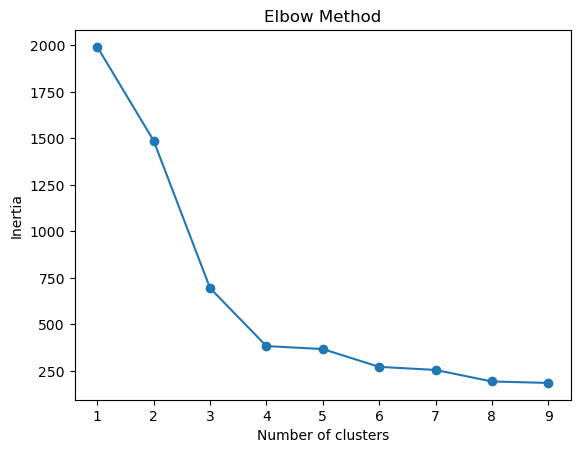

```python
# Detect the optimal number of clusters for k-means clustering using elbow method
inertia = []
for k in range(1, 10):
    kmeans = KMeans(n_clusters=k, random_state=42).fit(penguins_preprocessed)
    inertia.append(kmeans.inertia_)
plt.plot(range(1, 10), inertia, marker='o')
plt.xlabel('Number of clusters')
plt.ylabel('Inertia')
plt.title('Elbow Method')
plt.show()
```

```python
n_clusters=4
```

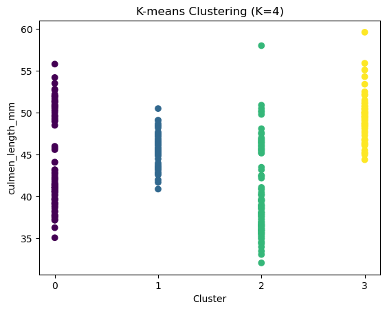

```python
# Run the k-means clustering with k=4
kmeans = KMeans(n_clusters=n_clusters, random_state=42).fit(penguins_preprocessed)
penguins_df['label'] = kmeans.labels_

# visualize the clusters (here for the 'culmen_length_mm' column)
plt.scatter(penguins_df['label'], penguins_df['culmen_length_mm'], c=kmeans.labels_, cmap='viridis')
plt.xlabel('Cluster')
plt.ylabel('culmen_length_mm')
plt.xticks(range(int(penguins_df['label'].min()), int(penguins_df['label'].max()) + 1))
plt.title(f'K-means Clustering (K={n_clusters})')
plt.show()
```

```python
# create `stat_penguins` DataFrame
numeric_columns = ['culmen_length_mm', 'culmen_depth_mm', 'flipper_length_mm','label']
stat_penguins = penguins_df[numeric_columns].groupby('label').mean()
stat_penguins
```

| label | culmen_length_mm | culmen_depth_mm | flipper_length_mm |
| --- | --- | --- | --- |
| 0 | 43.878302 | 19.111321 | 194.764151 |
| 1 | 45.563793 | 14.237931 | 212.706897 |
| 2 | 40.217757 | 17.611215 | 189.046729 |
| 3 | 49.473770 | 15.718033 | 221.540984 |

# Final Thoughts:

The clusters seem to be well-separated, meaning K-means has identified distinct groups. However, clusters 0, 1, and 2 have overlapping culmen lengths, which may indicate that K=4 is slightly high, or that another clustering method (e.g., **DBSCAN or hierarchical clustering**) might yield better results.

### Cluster 3 (Yellow):

This cluster appears to have the highest culmen lengths, meaning these data points share a distinct trait that differentiates them from the rest.